# Domača naloga 4

Linearni modeli

Alen Kahteran

10. 12. 2020

Najprej si poglejmo podatke.

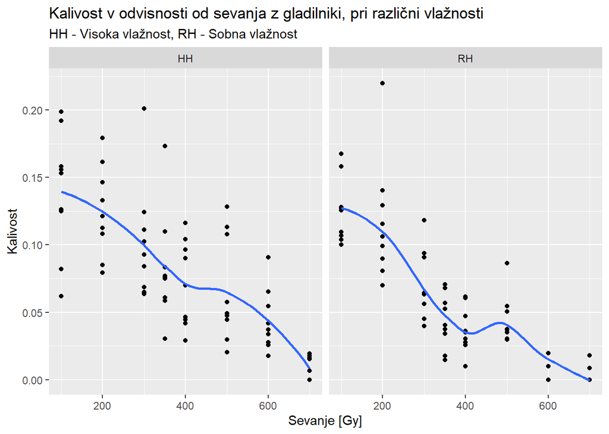

Vidimo, da tako pri visoki kot sobni vlažnosti kalivost pada z višjim sevanjem. Poglejmo si še podobno sliko, le da so tokrat oboji podatki za vlažnost na isti sliki.

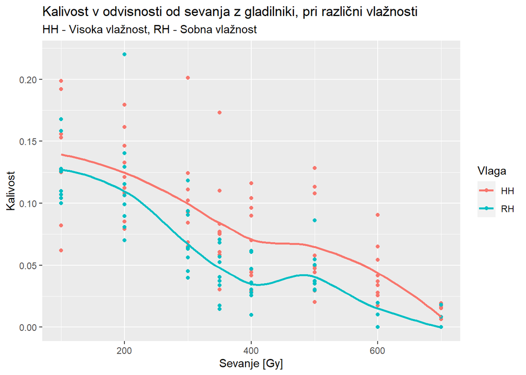

Iz tega grafa se da le razbrati, da je kalivost pri višji vlažnosti nekoliko boljša.

Sedaj si poglejmo diagnostične grafe modela `Kalivost` v odvisnosti od `Vlaga` in `Sevanje` in njune interakcije.

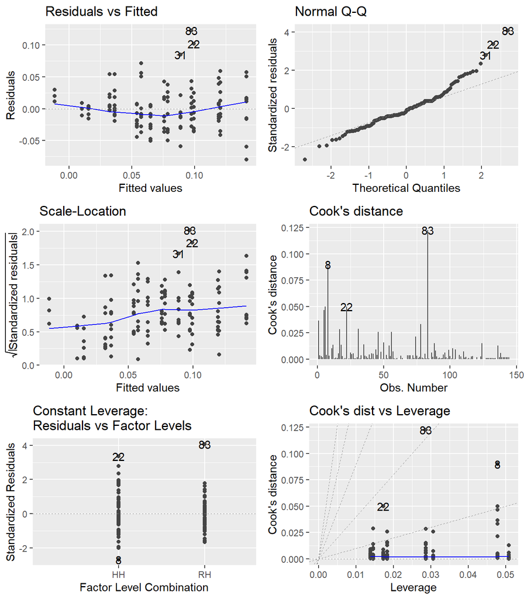

```r
mod_0 <- lm(Kalivost ~ Vlaga + Sevanje + Vlaga*Sevanje, data=pelod)
autoplot(mod_0, which = c(1:6))
```

Hitro vidimo da imamo težavo z naraščajočo varianco. Glede ne da to modeliramo `Kalivost`, ki je pravzaprav spremenljivka v obliki deleža, jo je potrebno smiselno transformirati. Uporabimo naslednjo transformacijo